# OpenStreetMap Data Case Study: East Bay, California

## Project Narrative

P3: Wrangle OpenStreetMap Data -- Udacity Data Science Nanodegree

Megan O'Neil

2016-11-21

## Map of the East Bay in the San Francisco Bay Area, California, United States

- https://mapzen.com/data/metro-extracts/your-extracts/ddd681acbf9f

I live in Oakland, California, which is in the East Bay of the San Francisco Bay Area. I’m interested to see what the database querying reveals about my hometown and broader East Bay community, and would like an opportunity to contribute to its improvement on OpenStreetMap.org. I am also interested in a Community Choice energy program which will create a public entity that procures electricity for the East Bay. I want the program to prioritize local renewable development, so am interested in learning to read maps of this area, as mapping is critical to understand what types of areas are suitable for solar or other renewable energy resources.

## Problems Encountered in the Map

I downloaded the map area, then used a small sample to try to find and assess issues with the data. I looked at street names, city names, postal codes, and names of amenities. I looked at street names, city names, and postal codes because I anticipated some inconsistencies in the data that I could clean, and amenities because I was interested in looking further at types and concentrations of the data, so wanted to make sure that typos in that data would cause issues.

### Street Types

I used the functions we developed in the course to audit the street types and find any which did not include expected types. After running the audit, I expanded the expected types to the following:

```
expected = ["Street", "Avenue", "Boulevard", "Drive", "Court", "Center", "Place", "Square", "Lane", "Road", "Trail", "Parkway", "Plaza", "Commons", "Way", "Circle", "Loop"]
```

```
special_map = {"Washington St 2nd Floor:": "Washington Street, 2nd Floor",
         "Telegraph": "Telegraph Avenue",
  "San Francisco/Oakland Bridge Toll Pl": "San Francisco/Oakland      Bridge Toll Plaza"
               }
```

These were special cases as my street cleaning function would not find the abbreviated ‘St’ since it was not the last word. The street ‘Telegraph’ did not have a street type, however I know the only Telegraph in the Bay Area is ‘Telegraph Avenue’, so I included that special correction case.

### City Names

I ran an audit on city names to assess if there were common errors or typos that I could correct, similar to street types. After running the audit, I created a city_mapping list to correct errors in common city names.

```
city_mapping = { "Alamda": "Alameda",
            "alameda": "Alameda",
            "Berkeley, CA": "Berkeley",
            "berkeley": "Berkeley",
            "Oakland ": "Oakland",
            "oakland": "Oakland",
            "Oakland CA": "Oakland",
            "Oakland, CA": "Oakland",
            "Oakland, Ca": "Oakland",
            "Okaland": "Oakland",
            "OAKLAND": "Oakland"
          }
```

I applied this function to clean common errors in the 'shape_element' function, though I did not exclude other unexpected city names from the ultimate SQL database.

### Zip Codes

I also ran an audit on a sample of zip codes to assess what inconsistencies there were and found that the most common errors in the postal code entries were:

- Spaces in entry
- Inclusion of ‘ca’ or ‘CA’ for California
- Inclusion of the last 4 digits of the extended zip+4 code
- Fewer than 5 digits in the zip code

I wrote the ‘clean_zip’ function to deal with these issues, which I called in the ‘shape_element’ function. Zip codes that were 5 digits after the cleaning were included in the .csv files to go into the database.

### Amenities

I also wrote a function to assess the unique amenity types to make sure there were no typos. However, I found no obvious typos so did no further cleaning.

## Data Overview

### File Sizes

```
eastbay.osm    92MB
eastbay.db    55MB
nodes.csv    33MB
nodes_tags.csv    2MB
ways.csv    3MB
ways_tags.csv    9MB
ways_nodes.csv    10MB
```

### Number of nodes

```
QUERY = '''
SELECT COUNT(*)
FROM nodes;'''
```

399495

### Number of ways

```
QUERY = '''
SELECT COUNT(*)
FROM ways;'''
```

54802

### Assessing the Users

#### Number of unique users

```
QUERY = '''
SELECT COUNT(DISTINCT(e.uid))
FROM (SELECT uid FROM nodes UNION ALL SELECT uid FROM ways) e;'''
```

866

```
QUERY = '''
SELECT DISTINCT(e.user), COUNT(*) as count
FROM (SELECT user FROM nodes UNION ALL SELECT uid FROM ways) e
GROUP BY e.user
ORDER BY count DESC
LIMIT 10;'''
```

[(u'oba510', 44550), (u'JessAk71', 34442), (u'EranChazan', 30821), (u'dchiles', 29208), (u'KindredCoda', 26654), (u'lyzidiamond', 23097), (u'David Muir Sharnoff', 20670), (u'Speight', 16582), (u'beej71', 15991), (u'nmixter', 10710)]

#### Number of users with only one post

```
QUERY = '''
SELECT COUNT(*)
FROM (SELECT e.user, COUNT(*) as num
FROM (SELECT user FROM nodes UNION ALL SELECT uid FROM ways) e
GROUP BY e.user
HAVING num=1) u;
'''
```

289 - 33% of all users have posted only once!

#### Number of users with more than 100 posts

```
QUERY = '''
SELECT COUNT(*)
FROM (SELECT e.user, COUNT(*) as num
FROM (SELECT user FROM nodes UNION ALL SELECT uid FROM ways) e
GROUP BY e.user
HAVING num > 100) u;'''
```

246 - 28% of users have posted over 100 times

## Data Exploration

### Top 10 appearing amenities

```
QUERY = '''
SELECT tags.value, COUNT(*) as count
FROM (SELECT * FROM nodes_tags
      UNION ALL
      SELECT * FROM ways_tags) tags
WHERE tags.key='amenity'
GROUP BY tags.value
ORDER BY count DESC;'''
```

```
[(u'parking', 1707),
 (u'restaurant', 906),
 (u'place_of_worship', 469),
 (u'school', 423),
 (u'cafe', 317),
 (u'bench', 242),
 (u'fast_food', 208),
 (u'bicycle_parking', 201),
 (u'drinking_water', 199),
 (u'toilets', 144)]
```

Good to see bicycle parking makes the top 10!

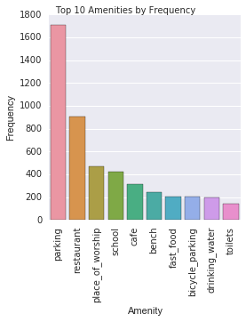

```python
from IPython.display import Image
Image(filename='top10amenities.png')
```

### Bicycle Parking

I am a bicyclist and care about bicycle parking and bike related amenities, so I decided to dig more into the amount of bike parking and the users contributing to it on the map.

#### Average capacity of bicycle parking

```
QUERY = '''
SELECT AVG(CAST(nodes_tags.value as INTEGER))
FROM nodes_tags
    JOIN (SELECT DISTINCT(id) FROM nodes_tags WHERE value='bicycle_parking') i
    ON nodes_tags.id = i.id
    WHERE nodes_tags.key = 'capacity';'''
```

10.74

#### Capacity of top 10 biggest bicycle parking stations

```
QUERY = '''
SELECT CAST(nodes_tags.value as INTEGER)
FROM nodes_tags
    JOIN (SELECT DISTINCT(id) FROM nodes_tags WHERE value='bicycle_parking') i
    ON nodes_tags.id = i.id
    WHERE nodes_tags.key = 'capacity'
    ORDER BY cast(nodes_tags.value as INTEGER) DESC
    LIMIT 10;'''
```

[(268,), (50,), (40,), (32,), (30,), (30,), (28,), (24,), (22,), (20,)]

#### Find out more details about this giant bicycle parking station!

```
SELECT *
FROM nodes_tags
    JOIN (SELECT DISTINCT(id) FROM nodes_tags WHERE key = 'capacity' AND value='268') i
    ON nodes_tags.id = i.id
  ;'''
```

Full results in python file - it's the Downtown BART Berkeley Bike Station, good to know! It also has a bike pump, repair facility, and bike retail.

#### Number of users adding bicycle parking amentiies

```
QUERY = '''
SELECT COUNT(DISTINCT(uid))
FROM nodes_tags JOIN nodes ON nodes_tags.id = nodes.id
WHERE nodes_tags.key = 'amenity' and nodes_tags.value = 'bicycle_parking' ;'''
```

15

#### Number of bicycle parking entries each user added

```
QUERY = '''
SELECT DISTINCT(nodes.user), COUNT(*) as count
FROM nodes_tags JOIN nodes ON nodes_tags.id = nodes.id
WHERE nodes_tags.key = 'amenity' and nodes_tags.value = 'bicycle_parking'
GROUP BY nodes.user
ORDER BY count DESC;'''
```

```
[(u'dchiles', 117),
 (u'JessAk71', 42),
 (u'beej71', 8),
 (u'oba510', 6),
 (u'Bryce C Nesbitt', 5),
 (u'zoeplankton', 5),
 (u'P Dill', 4),
 (u'Emers', 3),
 (u'David Muir Sharnoff', 1),
 (u'Kim Mason', 1),
 (u'Speight', 1),
 (u'lucioperca', 1),
 (u'mvexel', 1),
 (u'timheidinger', 1),
 (u'will l', 1)]
```

### Top 10 most popular shop types

```
QUERY = '''
SELECT nodes_tags.value, COUNT(*) as num
FROM nodes_tags
    JOIN (SELECT DISTINCT(id) FROM nodes_tags WHERE key='shop') i
    ON nodes_tags.id = i.id
WHERE key = 'shop'
GROUP BY nodes_tags.value
ORDER BY num DESC
LIMIT 10;'''
```

```
[(u'convenience', 100),
 (u'clothes', 98),
 (u'hairdresser', 92),
 (u'car_repair', 88),
 (u'beauty', 57),
 (u'bakery', 51),
 (u'supermarket', 45),
 (u'bicycle', 33),
 (u'books', 33),
 (u'alcohol', 32)]
```

Bikes are tied with books, two things I love! At least they made the top 10. Number 1 confirms we do live in a convenience economy...

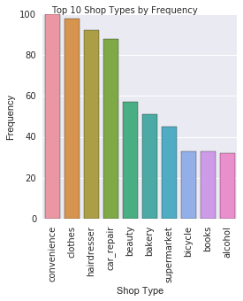

```python
from IPython.display import Image
Image(filename='top10shops.png')
```

### Cuisines

I also like eating! So here is a series on cuisines. My favorite types of food are Mexican, Indian, Korean, and Ethiopian.

#### Top 10 most popular cuisines

```
QUERY = '''
SELECT nodes_tags.value, COUNT(*) as num
FROM nodes_tags
    JOIN (SELECT DISTINCT(id) FROM nodes_tags WHERE value='restaurant') i
    ON nodes_tags.id = i.id
WHERE nodes_tags.key='cuisine'
GROUP BY nodes_tags.value
ORDER BY num DESC
LIMIT 10;'''
```

```
[(u'mexican', 42),
 (u'pizza', 37),
 (u'thai', 35),
 (u'chinese', 34),
 (u'japanese', 31),
 (u'american', 25),
 (u'burger', 21),
 (u'indian', 18),
 (u'italian', 18),
 (u'sushi', 16)]
```

I guess I live in the right place! Mexican at number 1 and Indian makes the top 10. What about the others?

[figure not shown]

```python
from IPython.display import Image
Image(filename='top10shops.png')
```

#### How many Korean & Ethiopian?

```
QUERY = '''
SELECT nodes_tags.value, COUNT(*) as num
FROM nodes_tags
    JOIN (SELECT DISTINCT(id) FROM nodes_tags WHERE value='restaurant') i
    ON nodes_tags.id = i.id
WHERE nodes_tags.key='cuisine'
AND nodes_tags.value = 'korean'
OR nodes_tags.value = 'ethiopian'
GROUP BY nodes_tags.value
ORDER BY num DESC
LIMIT 10;'''
```

```
[(u'korean', 5), (u'ethiopian', 2)]
```

### Energy

I am also interested in renewable energy. Let's find out about energy generation.

#### What information is there about energy nodes?

```
QUERY = '''
SELECT nodes_tags.value, COUNT(*) as count
FROM nodes_tags

WHERE nodes_tags.key='power'
GROUP BY nodes_tags.value
ORDER BY count DESC;'''

c.execute(QUERY)
all_rows = c.fetchall()
pprint(all_rows)
```

```
[(u'tower', 772), (u'generator', 22), (u'substation', 2)]
```

#### What type of generators?

```
QUERY = '''
SELECT DISTINCT(nodes_tags.value)
FROM nodes_tags
    JOIN (SELECT DISTINCT(id) FROM nodes_tags WHERE value='generator') i
    ON nodes_tags.id = i.id
    WHERE nodes_tags.key = 'source'
    ORDER BY nodes_tags.value;'''
```

All solar

#### Where?

```
QUERY = '''
SELECT DISTINCT(nodes_tags.value)
FROM nodes_tags
    JOIN (SELECT DISTINCT(id) FROM nodes_tags WHERE value='generator') i
    ON nodes_tags.id = i.id
    WHERE nodes_tags.key = 'place'
    ORDER BY nodes_tags.value;'''
```

It turns out all of the energy generators listed in the dataset are rooftop solar. The information provided about each includes place (roof), power (generator), source (solar), and for some that the output is electricity, small installation.

## Ideas about the Datasets

The database for the East Bay appears to be fairly clean. It is good to see that one or two users are not dominating the entries for the area; the top user is only responsible for 10% of entries, rather than over 50% as in Charlotte, NC, where a similar analysis was conducted. This is not too surprising for the Bay Area, a tech hub with large interest in open source information.

### Gamification

However, it is clear that the map is not comprehensive for the East Bay. (I can name more than 2 Ethiopian places!) Finding a way to increase interest in the database, perhaps by creating some 'gamification' of the map could spur more users to add information. This could be put in place through leaderboards of users. I am new to open source data entry, so credit this concept to a fellow Udacity student who suggested this method in the sample SQL project. (Ref: https://gist.github.com/carlward/54ec1c91b62a5f911c42#file-sample_project-md)

One potential problem with gamification is that users may add information that is not accurate in an effort to be on the leaderboard, as it is harder to track quality entries than simply number of entries. This would be counterproductive given time and effort required to clean and correct information. However, if there was a way to similiarly track and incentivize cleaning of map data, that part of the problem could be addressed.

### Renewable Energy

I would like to see additional information on energy generation in this map. There are far more than 22 rooftop solar installations. It would be useful to include data on solar throughout the bay area, including kW capacity of each solar PV system. This could be facilitated through data from *The Open PV Project Database*, (https://openpv.nrel.gov/) a collaborative effort project with the National Renewable Energy Laboratory, government, industry, and the public, which tracks the real-time status of the solar photovoltaic market in the U.S. This data could be used to demonstrate the concentration of solar panels in different neighborhoods, potentially indicating neighborhoods that could be targeted to increase solar installations.

Data could also be added from the EPA's RE-Powering Mapping and Screening Tools (https://www.epa.gov/re-powering/re-powering-mapping-and-screening-tools) databases, which include information on renewable energy potential on contaminated lands, landfills, and mine sites. By overlaying this information with the OSM data, it will be possible to zero in on the best spots for solar energy. This could be particularly useful to find contaminated areas that cannot be developed in urban areas, but could be utilized for a local community solar facility, enabling renters to benefit from solar energy by buying shares of a local solar facility. This can be made possible when Alameda County's Community Choice energy program is launched in 2017, and this type of mapping will be crucial to determine where local renewable development is best suited.

I do not envision any significant drawbacks to including this data, as I believe it is quite accurate per the EPA's records. I have not explored the data in detail so it may not be as useful as I expect for this purpose, though I am certain others may find it useful for other purposes. For example, it could be used to assess the proximity of different neighborhoods or amenities to contaminated lands.